# VisioProt - Utilisation manual

Marie Locard-Paulet

Wed Mar 14 18:46:42 2018

# General description

VisioProt-MS plots the masses of eluting proteins as a function of their retention time to allow inspection and analysis of runs from liquid chromatography coupled to mass spectrometry (LC-MS). The Shiny-based web application VisioProt-MS is suitable for non-R users. It can be found on our [team's webpage](https://masstools.ipbs.fr/mstools/visioprot-ms/) and the corresponding scripts are accessible [here](https://github.com/mlocardpaulet/VisioProt-MS). It is governed by the [CeCILL license](http://www.cecill.info).

## Input files

Here are examples of the 3 supported format files (5 first rows of the input tables):

**RoWinPro export:**

| V1 | V2 | V3 | V4 |
| --- | --- | --- | --- |
| 17.11 | 6572.2 | 10300000 | 1.092727e+12 |
| 17.11 | 6587.9 | 790000 | 4.930390e+08 |
| 17.11 | 6734.3 | 752000 | 4.252590e+08 |
| 17.11 | 6896.8 | 268000 | 1.924883e+07 |
| 17.11 | 6596.6 | 225000 | 1.139063e+07 |

**Bruker export:**

| V1 | V2 | V3 | V4 |
| --- | --- | --- | --- |
| Cmpd 1; Dissect; 10.84 min | 10.84025 | 1240.7088 | 265.2496 |
| Cmpd 1; Dissect; 10.84 min | 10.84025 | 621.8144 | 338.5613 |
| Cmpd 1; Dissect; 10.84 min | 10.84025 | 1272.5008 | 274.3401 |
| Cmpd 1; Dissect; 10.84 min | 10.84025 | 1332.6285 | 425.5195 |
| Cmpd 1; Dissect; 10.84 min | 10.84025 | 1023.6679 | 772.4701 |

**BioPharma Finder export:**

| Monoisotopic.Mass | Sum.Intensity | Relative.Abundance | Fractional.Abundance | Number.of.Charge.States | Charge.State.Distribution | Number.of.Detected.Intervals | Delta.Mass | Scan.Range | Start.Time..min. | Stop.Time..min. | Apex.RT | X |
| --- | --- | --- | --- | --- | --- | --- | --- | --- | --- | --- | --- | --- |
| 23428.57 | 4.09e+08 | 100.00 | 36.76 | 19 | 14 - 32 | 65 | 0.000 | 186 - 286 | 6.015 | 8.969 | 6.3037 | 2.954 |
| 25367.56 | 2.43e+08 | 59.41 | 21.84 | 21 | 15 - 35 | 51 | 1938.988 | 224 - 286 | 7.117 | 8.969 | 7.3494 | 1.852 |
| 25220.49 | 1.07e+08 | 26.19 | 9.63 | 19 | 17 - 35 | 78 | 1791.920 | 151 - 283 | 4.996 | 8.876 | 5.3201 | 3.880 |
| 25382.52 | 9.65e+07 | 23.63 | 8.68 | 18 | 17 - 34 | 68 | 1953.952 | 148 - 285 | 4.902 | 8.935 | 5.2915 | 4.033 |
| 23410.54 | 3.37e+07 | 8.25 | 3.03 | 14 | 20 - 33 | 29 | -18.022 | 185 - 221 | 5.985 | 7.058 | 6.2757 | 1.073 |

## Test mode

It is possible to check the box `Using test mode (to test the app. whithout input file-s)` to test the app without loading any input file. Upon checking the box, two buttons appear:

- `Single test file` uploads a test file in a RoWinPro format.
- `Multiple test files` uploads three files from a RoWinPro export. These are plotted together in order to be compared.

## Colours

Two sets of colour schemes are available for plotting single or multiple files:

**Colour schemes for single files:**

These have been chosen to visualise the signal intensities in a single file.

Spectral:

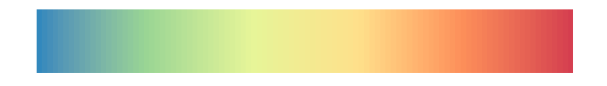

Red/yellow/blue:

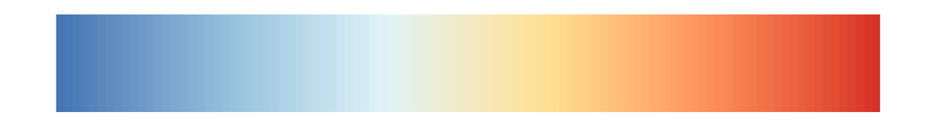

Red/yellow/green:

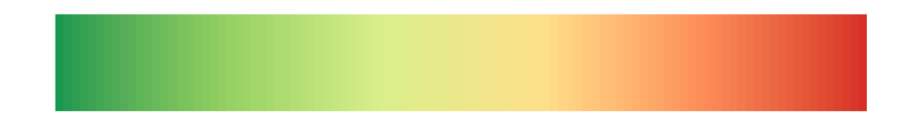

yellow to red:

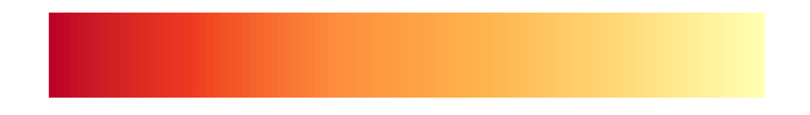

**Colour schemes for multiple files:**

These have been chosen to differenciate the signal from the distinct files.

Set1:

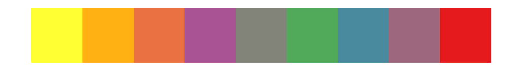

Set2:

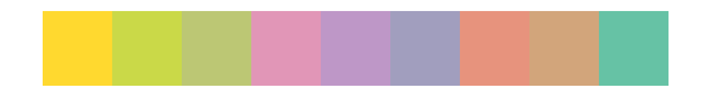

Set3:

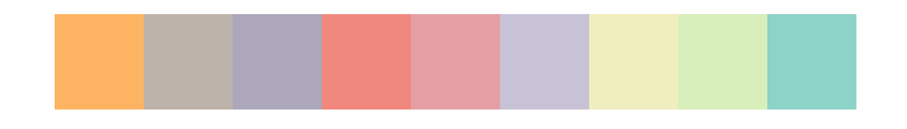

Dark2:

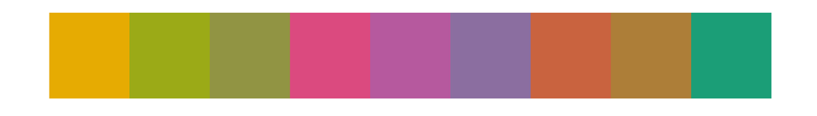

Paired:

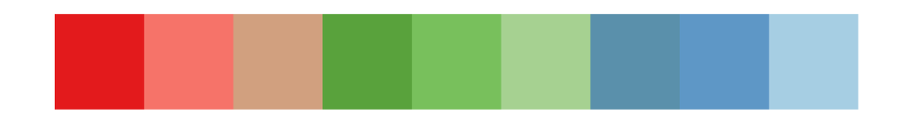

Accent:

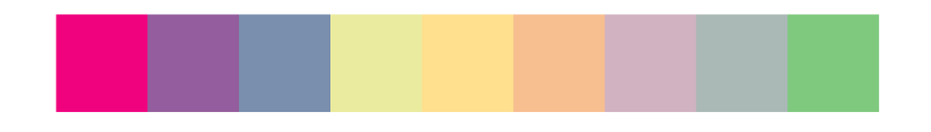